# Homework #10: Clustering

## c. Implement model-based clustering

- Describe any pre-processing steps you took (e.g., scaling)
- State the number of segments/clusters you used with justification.
- Describe the best model. What restrictions are on the shape of the components?
- Using your segmentation, are customers 1 and 100 in the same cluster?

```r
data_mb_cluster = Mclust(data_scaled)
summary(data_mb_cluster)
```

```
----------------------------------------------------
Gaussian finite mixture model fitted by EM algorithm
----------------------------------------------------

Mclust VVE (ellipsoidal, equal orientation) model with 9 components:

 log-likelihood     n df    BIC     ICL
         -46272 10000 86 -93336 -100859

Clustering table:
   1    2    3    4    5    6    7    8    9
 713  596 1789 1365 1725  392  735 1762  923
```

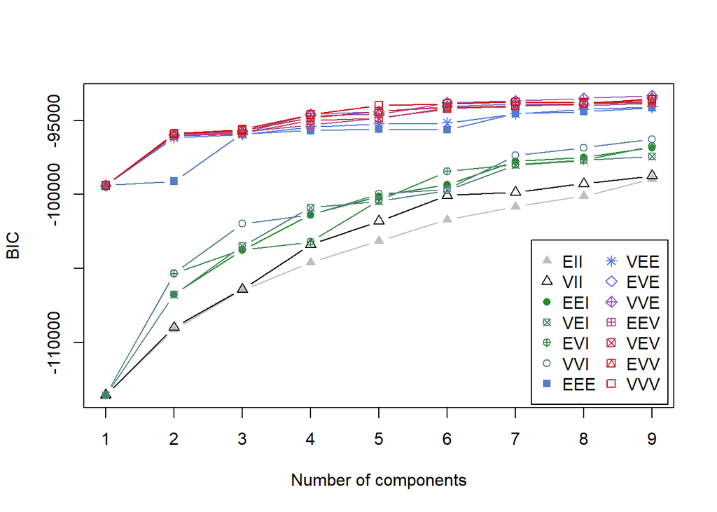

```r
plot(data_mb_cluster, what = "BIC")
```

```r
#Best Model, VVE
data_mb_cluster$modelName
```

```
[1] "VVE"
```

```r
summary(data_mb_cluster, parameters = TRUE)
```

```
----------------------------------------------------
Gaussian finite mixture model fitted by EM algorithm
----------------------------------------------------

Mclust VVE (ellipsoidal, equal orientation) model with 9 components:

 log-likelihood     n df    BIC     ICL
         -46272 10000 86 -93336 -100859

Clustering table:
   1    2    3    4    5    6    7    8    9
 713  596 1789 1365 1725  392  735 1762  923

Mixing probabilities:
     1      2      3      4      5      6      7      8      9
0.0595 0.0596 0.2128 0.1176 0.1910 0.0445 0.0741 0.1621 0.0788

Means:
             [,1]   [,2]   [,3]    [,4]    [,5]    [,6]   [,7]   [,8]   [,9]
id        -1.5742 -0.956 -0.242 -1.1482  0.0348 -0.0152  0.733  0.969  1.522
Recency   -0.3525  1.666 -0.543 -0.3579 -0.2038  1.9422  1.679 -0.414 -0.325
Frequency  0.0565 -0.314  0.581  0.0822 -0.4498 -1.4645 -0.308  0.230  0.238
Monetary   0.0181 -0.288  0.533  0.0785 -0.4370 -1.3167 -0.214  0.200  0.241

Variances:
[,,1]
                id  Recency Frequency Monetary
id         0.01010 -0.00283  -0.00794  -0.0100
Recency   -0.00283  0.31287  -0.03384  -0.0196
Frequency -0.00794 -0.03384   0.80076   0.6844
Monetary  -0.01004 -0.01960   0.68435   0.8442
[,,2]
                id  Recency Frequency Monetary
id         0.20103 -0.00160  -0.00625 -0.00588
Recency   -0.00160  0.36990  -0.02842 -0.00929
Frequency -0.00625 -0.02842   0.65869  0.53352
Monetary  -0.00588 -0.00929   0.53352  0.69296
[,,3]
                id  Recency Frequency Monetary
id         0.32105  0.00143  -0.00877  -0.0074
```

[output cut: 24 more lines]

```
Recency    0.000714  0.334729  -0.02913 -0.01273
Frequency -0.006726 -0.029126   0.68542  0.56539
Monetary  -0.003783 -0.012735   0.56539  0.72159
[,,8]
                id Recency Frequency Monetary
id         0.10120 -0.0015  -0.00941  -0.0107
Recency   -0.00150  0.2841  -0.03786  -0.0289
Frequency -0.00941 -0.0379   0.94799   0.8057
Monetary  -0.01069 -0.0289   0.80574   0.9988
[,,9]
                id  Recency Frequency Monetary
id         0.01719 -0.00281  -0.00982  -0.0121
Recency   -0.00281  0.32695  -0.04082  -0.0270
Frequency -0.00982 -0.04082   0.97276   0.8449
Monetary  -0.01210 -0.02703   0.84495   1.0263
```

```r
data$Cluster3 = data_mb_cluster$classification

if(nrow(data) >= 100) {
  same_cluster = data$Cluster3[1] == data$Cluster3[100]
  print(paste("Customer 1 and Customer 100 are in the same cluster:", same_cluster))
} else {
  print("Customer 1 or 100 does not exist in the dataset.")
}
```

```
[1] "Customer 1 and Customer 100 are in the same cluster: TRUE"
```

## d. Discussion of results

Discuss how you would cluster the customers if you had to do this for your job. Do you think one model would do better than the others?

```r
# Model Based clustering, for added flexibility and accuracy on the separate groups.
```

# Problem 2: Poisson Mixture Model

The pmf of a Poisson random variable is:
$$\begin{align*}
f_k(x; \lambda_k) = \frac{\lambda_k^x e^{-\lambda_k}}{x!}
\end{align*}$$

A two-component Poisson mixture model can be written:
$$\begin{align*}
f(x; \theta) = \pi \frac{\lambda_1^x e^{-\lambda_1}}{x!} + (1-\pi) \frac{\lambda_2^x e^{-\lambda_2}}{x!}
\end{align*}$$

## a. Model parameters

What are the parameters of the model?

**Solution**

$$\lambda_1 \ , \
\lambda_2 \ , \
\pi$$

## b. Log-likelihood

Write down the log-likelihood for $n$ independent observations ($x_1, x_2, \ldots, x_n$).

**Solution**

$$\log L(\theta) = \sum_{i=1}^n \log \left(\pi \frac{\lambda_1^{x_i} e^{-\lambda_1}}{x_i!} + (1-\pi) \frac{\lambda_2^{x_i} e^{-\lambda_2}}{x_i!}
\right)$$

## c. Updating the responsibilities

Suppose we have initial values of the parameters. Write down the equation for updating the *responsibilities*.

**Solution**

$$\pi = \frac 1n \sum_{i=1}^n \gamma({z_i}_1)$$

## d. Updating the model parameters

Suppose we have responsibilities, $r_{ik}$ for all $i=1, 2, \ldots, n$ and $k=1,2$. Write down the equations for updating the parameters.

**Solution**

$$\pi = \frac 1n \sum_{i=1}^n {r_i}_1$$

## e. Fit a two-component Poisson mixture model

Fit a two-component Poisson mixture model. Report the estimated parameter values and show a plot of the estimated mixture pmf for the following data:

```r
#-- Run this code to generate the data
set.seed(123)             # set seed for reproducibility
n = 200                   # sample size
z = sample(1:2, size=n, replace=TRUE, prob=c(.25, .75)) # sample the latent class
theta = c(8, 16)          # true parameters
y = ifelse(z==1, rpois(n, lambda=theta[1]), rpois(n, lambda=theta[2]))
```

- Note: The function `poisregmixEM()` in the R package `mixtools` is designed to estimate a mixture of *Poisson regression* models. We can still use this function for our problem of pmf estimation if it is recast as an intercept-only regression. To do so, set the $x$ argument (predictors) to `x = rep(1, length(y))` and `addintercept = FALSE`.
  - Look carefully at the output from this model. The outputs use different names/symbols than what we used in the course notes. The `beta` values (regression coefficients) are on the log scale.

```r
result = poisregmixEM(y, x = rep(1, length(y)), addintercept = FALSE, k = 2)
```

```
number of iterations= 46
```

```r
# Extract parameters and convert from log scale
lambda_estimates = exp(result$beta)
# Mixing proportions
pi_estimates = result$lambda

# Print the results
print(paste("Estimated lambda1:", lambda_estimates[1]))
```

```
[1] "Estimated lambda1: 16.1447307969696"
```

```r
print(paste("Estimated lambda2:", lambda_estimates[2]))
```

```
[1] "Estimated lambda2: 7.88249084013031"
```

```r
print(paste("Estimated pi1:", pi_estimates[1]))
```

```
[1] "Estimated pi1: 0.728314499615953"
```

```r
print(paste("Estimated pi2:", pi_estimates[2]))
```

```
[1] "Estimated pi2: 0.271685500384047"
```

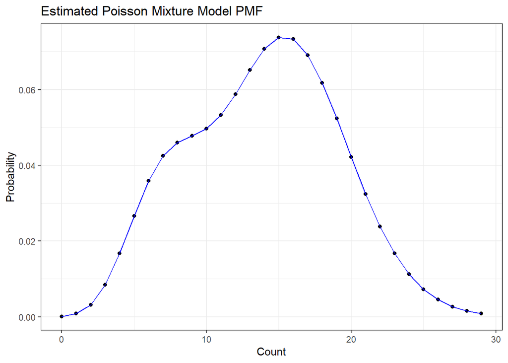

```r
x_vals = 0:max(y)
pmf = pi_estimates[1] * dpois(x_vals, lambda_estimates[1]) +
      pi_estimates[2] * dpois(x_vals, lambda_estimates[2])

# Create data frame for plotting
plot_data = data.frame(Counts = x_vals, PMF = pmf)

# Plotting
ggplot(plot_data, aes(x = Counts, y = PMF)) +
    geom_point() +
    geom_line(group = 1, colour = "blue") +
    labs(title = "Estimated Poisson Mixture Model PMF",
         x = "Count",
         y = "Probability")
```

## f. **2 pts Extra Credit** EM from scratch

Write a function that estimates this two-component Poisson mixture model using the EM approach. Show that it gives the same result as part *e*.

- Note: you are not permitted to copy code. Write everything from scratch and use comments to indicate how the code works (e.g., the E-step, M-step, initialization strategy, and convergence should be clear).
- Cite any resources you consulted to help with the coding.

**Solution**